# Допущения модели линейной регрессии и линеаризация зависимостей

Заходякин Г.В., postlogist@gmail.com

14.02.2017

```r
library(readr) # считывание данных из текстовых файлов
library(tidyverse) # манипулирование данными
library(ggplot2) # визуализация
library(ggfortify) # визуализация диагностических графиков
library(modelr) # вспомогательные функции для работы с моделями
library(broom) # преобразование результатов моделирования в табличный вид
library(GGally) # построение матрицы диаграмм рассеяния
library(car) # функции для степенных преобразований
```

# Модель линейной регрессии

Модель линейной регрессии позволяет предсказать **зависимую** переменную (dependent/output variable) на основе одной **объясняющей** переменной (explanatory/predictor variable). При этом предполагается, что связь между переменными линейна и для генеральной совокупности справедливо уравнение:

$$y = \beta_0 + \beta_1 x + \varepsilon$$

Параметры $\beta_0$ и $\beta_1$ определяют соответственно **свободный член** (intercept) и **угловой коэффициент** (slope) прямой линии. Свободный член $\beta_0$ - это ождидаемое значение $y$ при $x=0$. Угловой коэффициент $\beta_1$ отражает ожидаемое изменение $y$ при единичном увеличении $x$.

**Остаток** модели (error term) $\varepsilon$ включает отклонения отдельных наблюдений от предсказанных моделью ожидаемых значений, т.е. ошибку модели. Таким образом, каждое наблюдение $y_i$ можно рассматривать как сумму двух компонентов: закономерного (объясненного моделью):

$$\beta_0 + \beta_1 x_i,$$

и случайной ошибки:
$$\varepsilon_i.$$

Остаток модели включает действие всех факторов, влияющих на $y$, но не включенных в модель - т.е. всех факторов, кроме $x$.

# Допущения модели линейной регрессии

Остаток $\varepsilon$ - это важный компонент модели линейной регрессии. Именно свойства остатков используются для статистического вывода (оценки значимости модели) и интервального прогноза. Если аналитик хочет воспользоваться этими методами, то он должен убедиться в том, что исходные предположения модели не нарушены.

Перечислим эти предположения:

1. **Среднее значение остатка - нулевое** (нет систематической ошибки)

$$E(\varepsilon)=0$$

2. **Остатки модели некоррелированы между собой**:

$$\rho(\varepsilon_i, \varepsilon_k) = 0, \forall i \ne k$$

Если данное предположение нарушается, то модель будет неэффективной, т.е. можно построить более точную модель на тех же данных. Причина в том, что корреляция остатков между собой - это полезная информация, которая может быть учтена в модели для снижения ошибки.

3. **Остатки модели некоррелированы с объясняющей переменной**:

$$\rho(\varepsilon, x_j) = 0, \forall x_j$$

Это предположение распространяется и на другие переменные в наборе данных. Если есть зависимость остатков от другой переменной, то можно улучшить точность модели, включив в нее эту переменную.

4. **Дисперсия (и стандартное отклонение) остатков постоянна**, т.е. не зависит от $x$:

$$\sigma_\varepsilon = const, \forall x$$

Данное допущение называется **гомоскедастичностью** (homoscedasticity).

5. **Распределение остатков модели - нормальное**:
   $$\varepsilon \sim N(0, \sigma).$$

Эти предположения лежат в основе статистического вывода по модели и получения интервального прогноза.

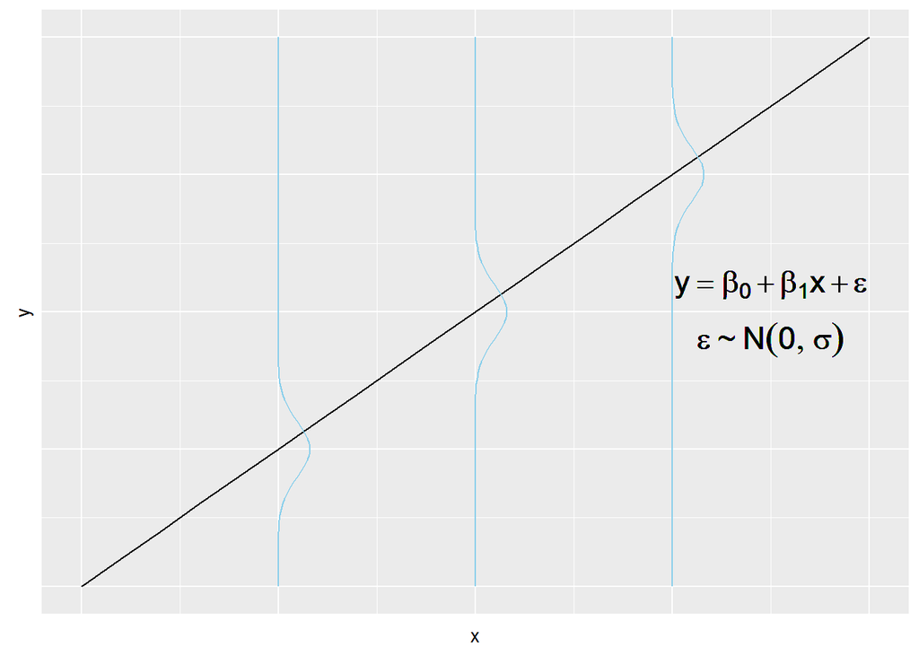

# Проверка допущений модели линейной регрессии (диагностика остатков)

Для диагностики остатков используются стандартные графики, которые можно получить, применив к модели функцию `autoplot()` (должны быть загружены пакеты `ggplot2` и `ggfortify`) или встроенную функцию `plot` (в этом случае будет использоваться базовая графика R, вместо ggplot2).

## Пример 1: хорошая модель, никакие допущения не нарушены

Генерация данных

```r
# Параметры модели:
beta0 <- 5
beta1 <- 1
sd_eps <- 2

# Генерация данных:
set.seed(123)
N <- 200


x <- runif(N, 0, 10)
eps <- rnorm(N, 0, sd_eps)
y <- beta0 + beta1 * x + eps
```

Построение модели

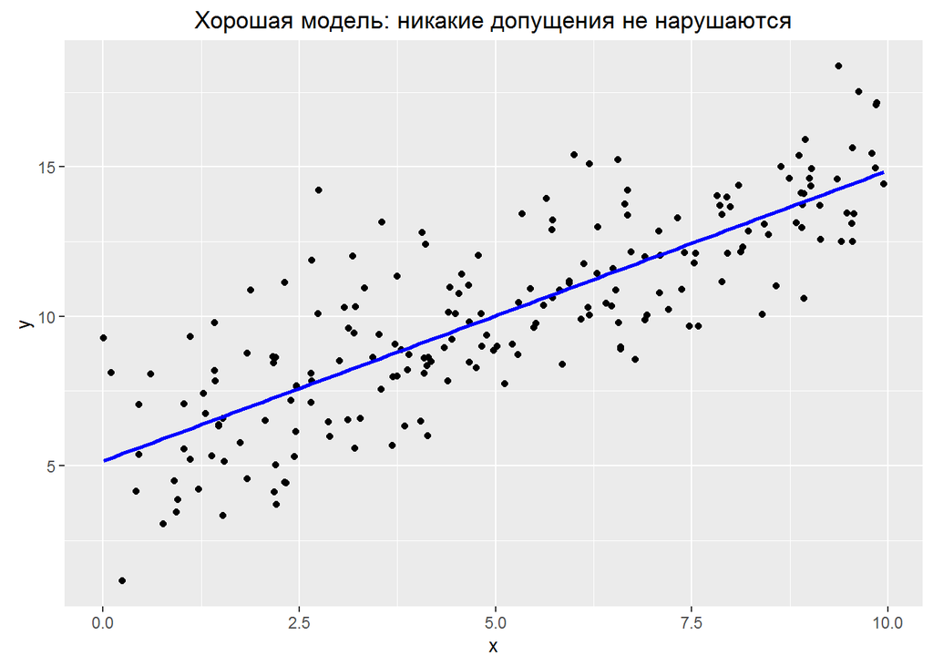

```r
m <- lm(y ~ x)

ggplot(tibble(x, y), aes(x, y)) +
  geom_point() +
  geom_smooth(method = lm, se = F, col = 'blue') +
  labs(title = 'Хорошая модель: никакие допущения не нарушаются')
```

```r
summary(m)
```

```
##
## Call:
## lm(formula = y ~ x)
##
## Residuals:
##    Min     1Q Median     3Q    Max
## -4.254 -1.250 -0.222  1.191  6.404
##
## Coefficients:
##             Estimate Std. Error t value Pr(>|t|)
## (Intercept)   5.1545     0.2872    17.9   <2e-16 ***
## x             0.9720     0.0499    19.5   <2e-16 ***
## ---
## Signif. codes:  0 '***' 0.001 '**' 0.01 '*' 0.05 '.' 0.1 ' ' 1
##
## Residual standard error: 1.93 on 198 degrees of freedom
## Multiple R-squared:  0.657,  Adjusted R-squared:  0.655
## F-statistic:  379 on 1 and 198 DF,  p-value: <2e-16
```

Диагностические графики для хорошей модели

Про выбор и настройку внешнего вида диагностических графиков можно прочитать [здесь](https://cran.r-project.org/web/packages/ggfortify/vignettes/plot_lm.html) и в справке: `?autoplot.lm`

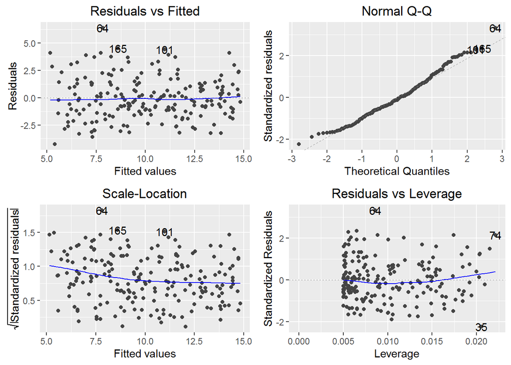

```r
autoplot(m)
```

Первый график показывает зависимость остатков модели $e$ от предсказанных значений $\hat{y}$.

Если допущения линейной регрессии верны, то не должно быть зависимости остатков от предскзанных значений. Искривленная форма облака точек на этом графике означает, что зависимость между $x$ и $y$ нелинейная и необходимо либо включать в модель нелинейные члены (степени $x$), либо использовать линеаризующее преобразование данных. На этом графике будет видна и гетероскедастичность, т.е. непостоянство дисперсии остатков. Если гетероскедастичность присутствует, то доверительные интервалы для прогнозов окажутся чрезмерно оптимистичными (их построение основано на допущении о том, что дисперсия остатков постоянна), также некорректными будут и результаты проверки гипотез о значимости модели и коэффициентов.

Наблюдения с наибольшими значениями остатков помечаются номерами строк (можно выбрать другую переменную для текста метки, см. `?autoplot.lm`).

Второй диагностический график позволяет проверить предположение о нормальности остатков:

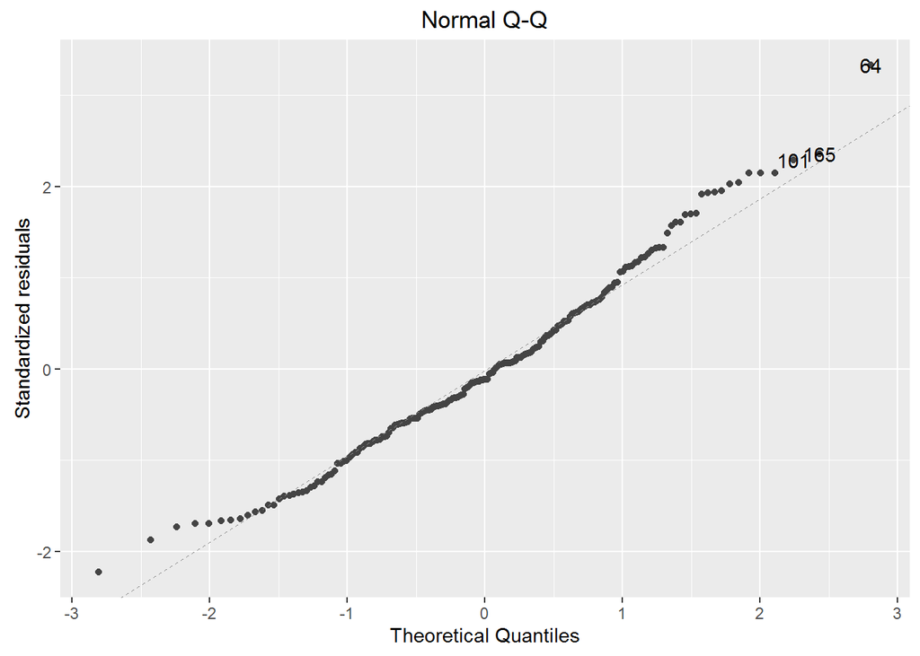

```r
autoplot(m, which = 2)
```

Это квантильный график для остатков. При справедливости допущения остатки на графике должны быть близкими к наклонной прямой линии.

Третий диагностический график позволяет обнаружить гетероскедастичность.

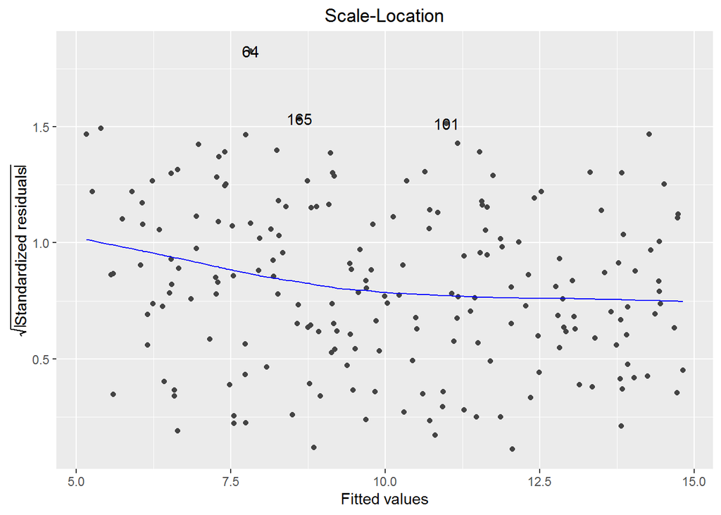

```r
autoplot(m, which = 3)
```

Если дисперсия остатков не постоянна, то облако точек будет искривленным или иметь воронкообразную форму. Здесь видно, что форма облака практически не изменяется в зависимости от $\hat{y}$, т.е. предположение о гомоскедастичности не нарушено.

Четвертый график помогает выявить выбросы и влиятельные наблюдения.

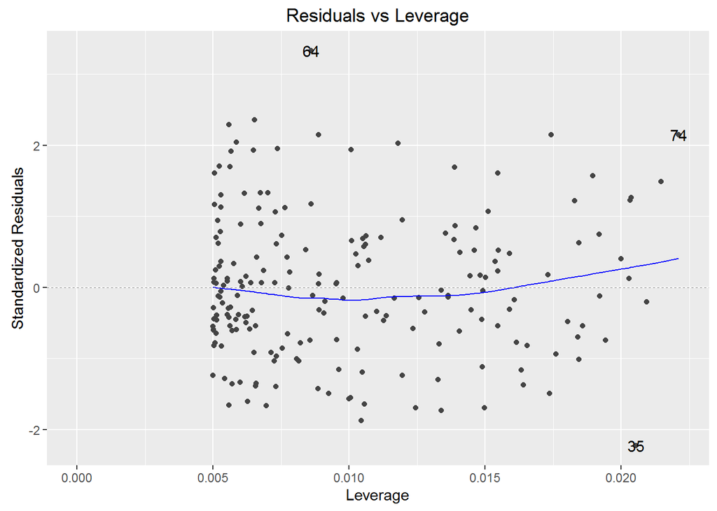

```r
autoplot(m, which = 5)
```

**Выброс** (outlier) - это наблюдения с большим остатком, т.е. наблюдение, для которого модель работает плохо.

**Влиятельное наблюдение** (influential observation) - наблюдение, которое сильно влияет на коэффициенты модели и полученный прогноз.

**Леверидж** (leverage) - это количественный показатель степени влияния наблюдения на модель - см. https://en.wikipedia.org/wiki/Leverage_(statistics).

Для расчета левериджа используется только значения объясняющих переменных $\mathbf X$. Эта величина показывает, насколько необычно значение $x$, т.е. насколько оно удалено от других с учетом только объясняющих переменных.

Другим способом оценить степень влияния наблюдения является **расстояние Кука** (Cook’s Distance) - см. https://en.wikipedia.org/wiki/Cook's_distance. Эта величина характеризует степень изменения коэффициентов модели, если данное наблюдение исключить при оценке модели. Влиятельными считаются наблюдения с $D > 1$, по другой оценке - с $D > 4/ n$, где $n$ - число наблюдений.

Можно вывести диагностический график, на котором для каждого наблюдения показаны обе эти величины.

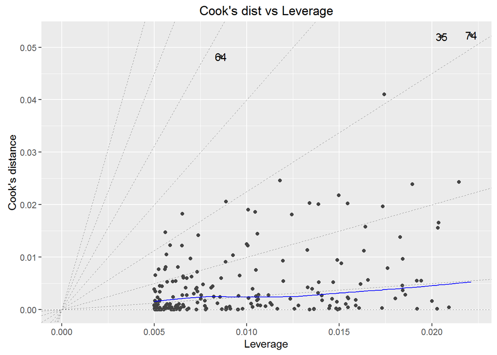

```r
autoplot(m, which = 6)
```

Влиятельные наблюдения необходимо внимательно изучить, поскольку они могут быть следствием ошибок при сборе или вводе данных и исказить результаты моделирования.

## Плохая модель: нелинейность

В этом примере мы сгенерируем случайные данные с использованием нелинейной зависимости:

```r
beta2 <- .5
# Добавим квадратичный член:
y_nonlin <- beta0 + beta1 * x + beta2 * x^2 + eps
```

Оценка модели:

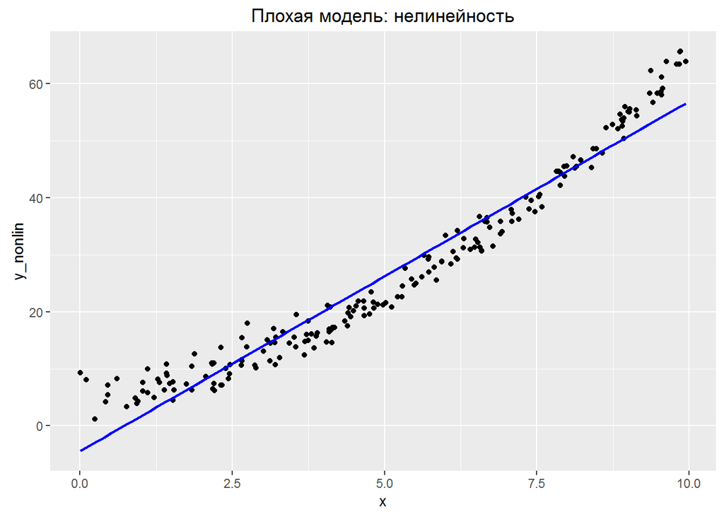

```r
m_nonlin <- lm(y_nonlin ~ x)

ggplot(tibble(x, y_nonlin), aes(x, y_nonlin)) +
  geom_point() +
  geom_smooth(method = lm, se = F, col = 'blue') +
  labs(title = 'Плохая модель: нелинейность')
```

```r
summary(m_nonlin)
```

```
##
## Call:
## lm(formula = y_nonlin ~ x)
##
## Residuals:
##    Min     1Q Median     3Q    Max
## -6.395 -3.429 -0.542  2.835 13.668
##
## Coefficients:
##             Estimate Std. Error t value Pr(>|t|)
## (Intercept)   -4.443      0.599   -7.41  3.5e-12 ***
## x              6.137      0.104   58.92  < 2e-16 ***
## ---
## Signif. codes:  0 '***' 0.001 '**' 0.01 '*' 0.05 '.' 0.1 ' ' 1
##
## Residual standard error: 4.03 on 198 degrees of freedom
## Multiple R-squared:  0.946,  Adjusted R-squared:  0.946
## F-statistic: 3.47e+03 on 1 and 198 DF,  p-value: <2e-16
```

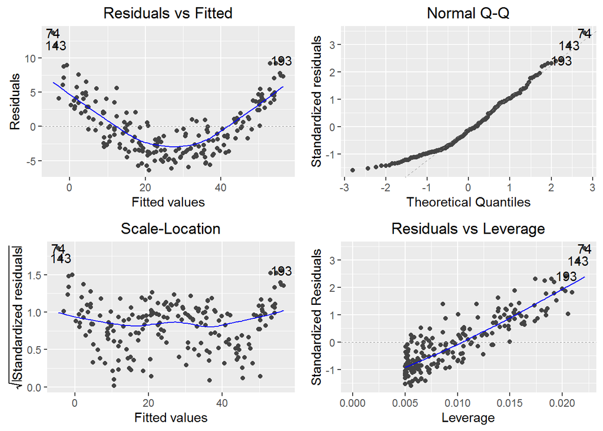

```r
autoplot(m_nonlin)
```

На первом диагностическом графике хорошо видно искривление облака точек. На квантильном графике отклонение от нормального распределения в области отрицательных остатков более заметно. На графике scale-location видно, что есть характерное изменение дисперсии остатков.

## Плохая модель 2: гетероскедастичность

В этом примере мы сгенерируем данные, в которых дисперсия остатков растет с увеличением $x$

```r
y_hetero <- beta0 + beta1 * x + eps * x / mean(x)
```

Оценка модели:

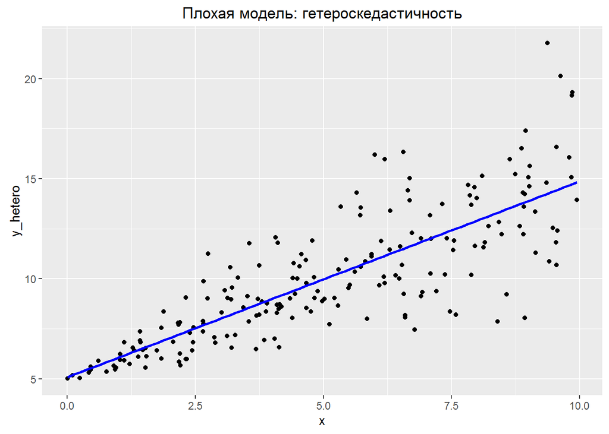

```r
m_hetero <- lm(y_hetero ~ x)

ggplot(tibble(x, y_hetero), aes(x, y_hetero)) +
  geom_point() +
  geom_smooth(method = lm, se = F, col='blue') +
  labs(title = 'Плохая модель: гетероскедастичность')
```

```r
summary(m_hetero)
```

```
##
## Call:
## lm(formula = y_hetero ~ x)
##
## Residuals:
##    Min     1Q Median     3Q    Max
## -5.769 -1.057 -0.107  0.889  7.533
##
## Coefficients:
##             Estimate Std. Error t value Pr(>|t|)
## (Intercept)   5.0792     0.2908    17.5   <2e-16 ***
## x             0.9788     0.0505    19.4   <2e-16 ***
## ---
## Signif. codes:  0 '***' 0.001 '**' 0.01 '*' 0.05 '.' 0.1 ' ' 1
##
## Residual standard error: 1.95 on 198 degrees of freedom
## Multiple R-squared:  0.655,  Adjusted R-squared:  0.653
## F-statistic:  375 on 1 and 198 DF,  p-value: <2e-16
```

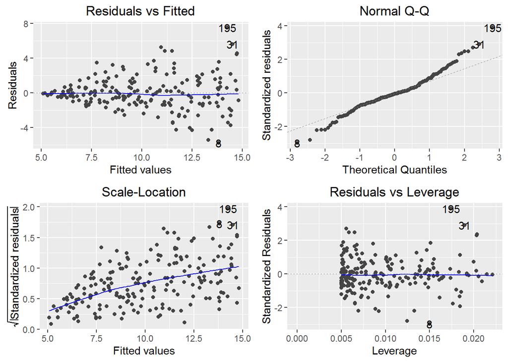

```r
autoplot(m_hetero)
```

На первом и третьем графиках видно, что облако точек имеет воронкообразную форму.

## Автокорреляция остатков

Случай взаимной зависимости (автокорреляции) остатков будет рассмотрен в лекции про регрессию для временных рядов.

# Что делать, если предположения линейной модели нарушаются?

Если проблема связана с нелинейностью данных или гетероскедастичностью, то можно попробовать преобразовать данные, чтобы минимизировать проявления этих нарушений.

## Преобразования для устранения гетероскедастичности

Непостоянство дисперсии - это распространенное явление в реальных данных, хотя оно может присутствовать в гораздо менее выраженной форме. Например, при увеличении зависимой переменной - дохода людей - увеличивается и степень неравенства между ними (дисперсия).

Для устранения гетероскедастичности можно применять к зависимой переменной нелинейные преобразования: - логарифм (logarithm transformation) - квадратный корень (square root transformation) - обратное значение (inverse transformation)

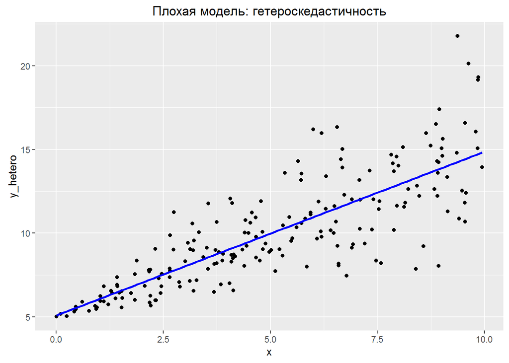

```r
# Исходные данные
ggplot(tibble(x, y_hetero), aes(x, y_hetero)) +
  geom_point() +
  geom_smooth(method = lm, se = F, col='blue') +
  labs(title = 'Плохая модель: гетероскедастичность')
```

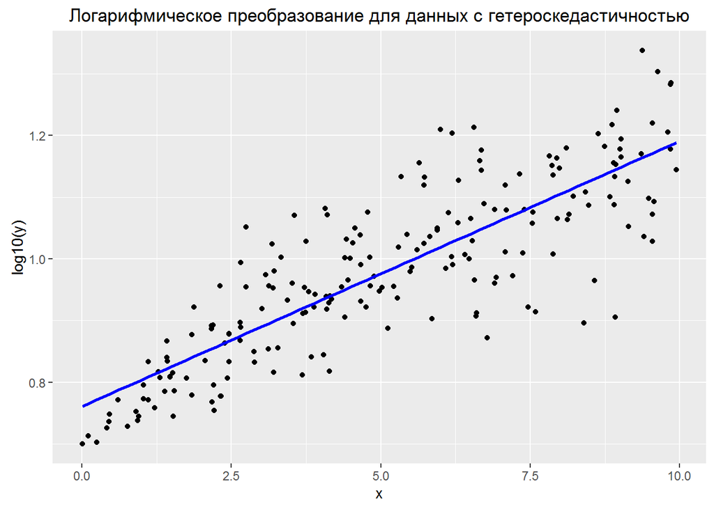

```r
# Логарифмирование
ggplot(tibble(x, y = log10(y_hetero)),
       aes(x, y))  +
         geom_point() +
         geom_smooth(method=lm, se=F, col='blue') +
         labs(title='Логарифмическое преобразование для данных с гетероскедастичностью',
              y = 'log10(y)')
```